# R Notebook

### Random Forests

```r
require(randomForest)
```

This builds a lot of trees, selecting a split parameter from a subset of parameters, and averages out to reduce the variance.

Creating a train-test split with 300-206 data observations each

```r
set.seed(101)
data(Boston)
index <- sample(1:nrow(Boston), 300)
```

We use random forest for regression, with ‘medv’ as the response variable and every other variable as the predictor.

```r
rf_boston <- randomForest(medv~., data = Boston, subset = index)
rf_boston
```

```
Call:
 randomForest(formula = medv ~ ., data = Boston, subset = index)
               Type of random forest: regression
                     Number of trees: 500
No. of variables tried at each split: 4

          Mean of squared residuals: 12.68651
                    % Var explained: 83.45
```

500 trees were grown. The number of variables at each split is 4, which is approximately sqrt(13), the number of parameters. The MSR is Out of Bag mean squared residuals.

m is the number of variables that is selected at each split in random. This is given by the mtry parameter in randomForest(). And this is one of the parameters that we can tune.

Building random forest decision trees with m ranging from 1 to 13 (p parameters), and recording the OOB and test errors

```r
oob_rf_error
```

```
 [1] 22.72616 14.62290 13.73073 12.79109 12.38863 12.69210 12.41103 12.44833 12.71799 13.08525 12.91090 12.60250 12.83121
```

Plotting the oob and test errors across m

- type = “b” means it plots both the points and connects them with lines

[figure not shown]

```r
matplot(1:m, cbind(test_rf_error, oob_rf_error), pch = 19, col = c("red", "blue"), type = "b", ylab = "Mean Squared Error")
legend("topright", legend = c("OOB", "Test"), pch = 19, col = c("red", "blue"))
```

### Boosting

We run a simple boositng logic on the same Boston data. We use the package “gbm” (Gradient Boosted Machines)

```r
require(gbm)
```

We ask for 10000 because there are a lot of shallow trees, with 4 depths. So, 4 splits choosing 4 variables.

|  | var | rel.inf |
| --- | --- | --- |
| lstat | lstat | 37.92700081 |
| rm | rm | 26.80915732 |
| dis | dis | 8.98001959 |
| crim | crim | 5.92133489 |
| age | age | 5.28582196 |
| nox | nox | 4.43997827 |
| black | black | 3.41087439 |
| ptratio | ptratio | 2.42402276 |
| tax | tax | 2.06599679 |
| indus | indus | 1.56393557 |

[output cut: 3 more lines]

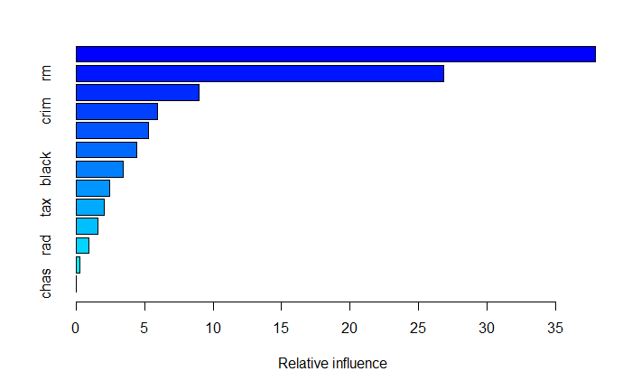

Summary gives the variable importance plot! The two variables that seem to be important are lstat and rm

Checking out the two variables, partial dependence plots

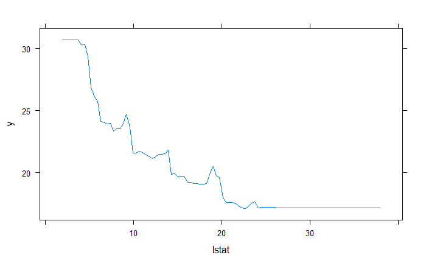

```r
par(mfrow = c(1,2))
plot(boost_boston, i = "lstat")
```

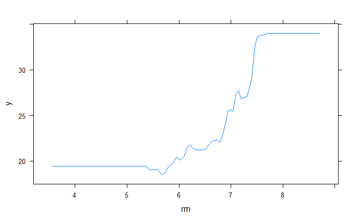

```r
plot(boost_boston, i = "rm")
```

Higher the proportion of lower status people in the suburb, lower the value of the house Higher the number of rooms in the house, higher the value of the house

Looking at the test performance as a function of the number of trees

```r
no_trees <- seq(from = 100, to = 10000, by = 100)
pred_matrix <- predict(boost_boston, newdata = Boston[-index,], n.trees = no_trees)
```

pred_matrix consists of a matrix of predictions of the test data. So, there are 206 observations of the test data, and 100 different tree predictions

Computing the test error

We have calculated the squared differences for each of the columns, and then we take the mean of each column. This computes the column-wise mean squared error

```r
boost_test_error <- with(Boston[-train,], apply((pred_matrix - medv)^2, 2, mean))
```

[output not shown]

Ploting the boosting test error and comparing it with the random forest error

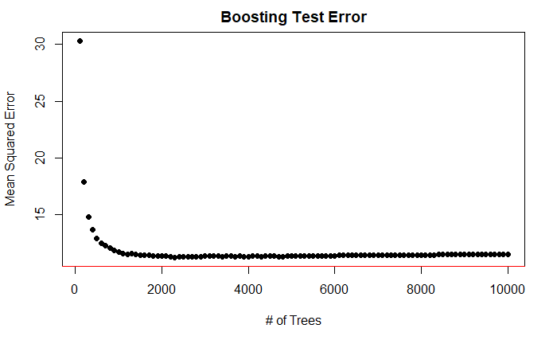

```r
plot(no_trees, boost_test_error, pch = 19, ylab = "Mean Squared Error", xlab = "# of Trees", main = "Boosting Test Error")
abline(h = min(test_rf_error), col = "red")
```

The test error drops down, but levels off. There is no real increase of decrease.